```python
import numpy as np
import matplotlib.pyplot as plt
import statsmodels.api as sm

from scipy.stats import probplot
from scipy.optimize import fsolve

rng = np.random.default_rng(seed=100)
```

# Statistics of poisson regression

Poisson regression is a method for estimating relationship between count data (in our case the number of reads supporting a k-mer in a sample) and a set of predictors (in our case sampling time). Standard software reports both a point estimate of the model parameters and also various measures of uncertainty. The latter depend of a set of approximations that are typically only true for sufficiently large datasets. By necessity, early warning systems will have to function when the total number of observations of a sequence is small, violating the assumptions of the approximation.

Here, I review the common frequentist statistical properties of a parameter estimate as applied to Poisson regression and use simulations to investigate the accuracy of the software-approximated measures of uncertainty.

## Model and definitions

We are interested in modeling count data with an exponentially growing mean. Consider sampling taking $n$ metagenomic samples at equal intervals paced $\Delta t$ apart. We observe a vector of counts of our k-mer of interest: $\vec{k} = \left( k_0, k_1, \ldots, k_{n-1} \right)$. Our model is that the $\left\{ k_j \right\}$ are independent with $$ k_j \sim \text{Poisson}\left( \lambda_j \right) \\ \lambda_j = \exp\left(\beta_0 + \beta_1 j\right) $$ The model has two coefficients:

1. The constant coefficient $\beta_0 = \log(a_0) + \log(c)$,

where $c$ is a lumped parameter containing information about the sampling effort, sequencing efficiency, and bioinformatics pipeline. 2. The linear coefficient $\beta_1 = r \Delta t$, where $r$ is the growth rate of the sequence of interest.

We are interested in generating estimates of these parameters, $\left(\hat{\beta_0}, \hat{\beta_1}\right)$ from $\vec{k}$.

### Maximum likelihood estimation

The log-likelihood of the parameters given the data in our model is: $$ \begin{align} l(\beta_0, \beta_1; \vec{k}) & = \sum_j k_j \log(\lambda_j) - \lambda_j \\ & = \sum_j \left\{ k_j (\beta_0 + \beta_1 j) - \exp(\beta_0 + \beta_1 j) \right\} \end{align} $$ so that the gradient is: $$ \begin{align} \frac{\partial l}{\partial \beta_0} & = \sum_j \left\{ k_j - \exp(\beta_0 + \beta_1 j)\right\} \\ \frac{\partial l}{\partial \beta_1} & = \sum_j \left\{ k_j j - \exp(\beta_0 + \beta_1 j) j\right\}. \end{align} $$ Solving for zero gradient gives the maximum likelihood estimates for $(\hat{\beta_0}, \hat{\beta_1})$: $$ \begin{align} \sum_j \exp(\hat{\beta_0} + \hat{\beta_1} j) & = \sum_j k_j \\ \sum_j j \exp(\hat{\beta_0} + \hat{\beta_1} j) & = \sum_j j k_j \end{align} $$

We can't solve these equations in closed form, so we turn to Poisson regression to estimate our parameters.

#### Aside

An aside for future investigation: the maximum likelihood estimates show that there are two *sufficient statistics* for estimating the parameters of our model: $\sum_j k_j$ and $\sum_j j k_j$. That is, these two quantities contain all of the information in our data that is relevent to inferring the coefficients. (By analogy, if we were trying to infer the mean and variance of a Gaussian distribution via maximum likelihood, the sample mean and variance are sufficient statistics.) Because these are both weighted sums, we can compute their cumulants (or moments) analytically. In fact, the distribution of $\sum_j k_j$ is Poisson($\sum_j \lambda_j$). It may be possible to use these facts to derive more accurate expressions for the sampling distributions of $\hat{\beta_0}$ and $\hat{\beta_1}$ without simulation.

### Poisson Regression

Poisson regression is a generalized linear model (GLM) that matches the model described above. GLMs are extensions of ordinary linear models to allow:

1. the mean of the response variable to be a nonlinear function of the dependent variables
2. the variance of the response variable to vary with the predictors (heteroskedacity).

A GLM is defined by a linear predictor $\eta$, a link function $g$, and a dispersion scale function $V$. In our case, the linear predictor is linear in the sampling index, $j$, $$ \eta(j) = \beta_0 + \beta_1 j. $$ The link function connects the linear predictor to the mean of the response variable (in our case $\mu(j) = k_j$) by the relationship $\eta(j) = g(\mu(j))$. Poisson regression uses the link function: $$ g(\mu_j) = \log(\mu_j), $$ representing exponential growth. Finally, the dispersion scale function captures the relationship between the mean and the variance of the response variable. Under the Poisson distribution, the mean and variance are equal, so Poisson regression uses the dispersion scale function: $$ V(\mu) = \mu. $$

GLMs are fit to data by the iterated reweighted least squares algorithm, which converges to the maximum likelihood estimate of the parameters.

We can fit a Poisson regression using the `GLM` object provided by `statsmodels`:

```python
def poisson_regression(k):
    return sm.GLM(
        k,
        sm.add_constant(np.arange(len(k))),
        family=sm.families.Poisson()
    ).fit()
```

Simuate poisson counts with exponentially growing expectation:

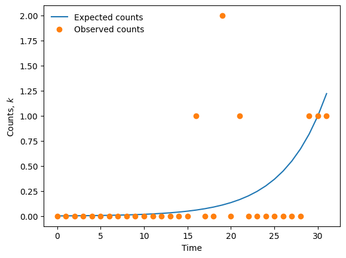

```python
len_series = 32
time = np.arange(len_series)
beta0_true = -6.0
beta1_true = 0.2
lambda_true = np.exp(beta0_true + beta1_true * time)

counts_obs = rng.poisson(lambda_true)
plt.plot(time, lambda_true, label="Expected counts")
plt.plot(time, counts_obs, 'o', label="Observed counts")
plt.xlabel('Time')
plt.ylabel('Counts, $k$')
plt.legend(loc='upper left')
```

Now we fit the model and print a summary of the output:

```python
fit = poisson_regression(counts_obs)
print(fit.summary())
```

```
                 Generalized Linear Model Regression Results
==============================================================================
Dep. Variable:                      y   No. Observations:                   32
Model:                            GLM   Df Residuals:                       30
Model Family:                 Poisson   Df Model:                            1
Link Function:                    Log   Scale:                          1.0000
Method:                          IRLS   Log-Likelihood:                -15.411
Date:                Tue, 08 Nov 2022   Deviance:                       18.209
Time:                        06:39:06   Pearson chi2:                     28.8
No. Iterations:                     5   Pseudo R-squ. (CS):             0.1669
Covariance Type:            nonrobust
==============================================================================
                 coef    std err          z      P>|z|      [0.025      0.975]
------------------------------------------------------------------------------
const         -3.7884      1.330     -2.847      0.004      -6.396      -1.181
x1             0.1139      0.054      2.105      0.035       0.008       0.220
==============================================================================
```

We will be examining several features of the output in depth in this notebook:

- `coef`: the inferred regression coefficients $\hat{\beta_0}$ (`const`) and $\hat{\beta_1}$ (`x1`)
- `std err`: an approximation to the standard error of the inferred coefficients
- `z`: the z-score or ratio of coofficient to standard error
- `P>|z|`: an approximation to the p-value of a two-sided hypothesis test. We will investigate whether these are well-callibrated
- `[0.025 0.975]`: an approximation to the 95% confidence interval. We will investigate the coverage of these intervals

The reported standard errors, p-values, and confidence intervals all make use of asymptotic approximations that tend toward the right values as the number of observations increases. In particular, the approximate standard errors are derived from the Fisher information, and the p-values and confidence intervals assume that the sampling distribution of coefficients is Gaussian with standard deviation equal to the estimated standard errors. In the rest of this notebook, we will investigate deviations from these assumptions in simulated Poisson count data.

Note that in real data there will be another, and potentially much larger source of error: the model's assumptions may be wrong. For example, the growth may be either faster or slower than exponential, or the counts may be overdispersed relative to the Poisson distribution. In this notebook we are not investigating those effects, we are only examanining the accuracy of the GLM software's approximations *assuming the model is exactly correct.* However, I hope that this notebook can serve as a template for future investigations.

## Illustrating miscalibration of p-values with an edge case

We'll start by illustrating the potential issues with the p-values with an extreme edge case. This case isn't particularly important in practice -- we can filter it out with a simple heuristic -- but it will show that we can't automatically rely on the p-values the software produces.

Consider the case where we observe a sequence of all zeros followed by a single one, $\vec{k} = (0, \ldots, 0, 1)$:

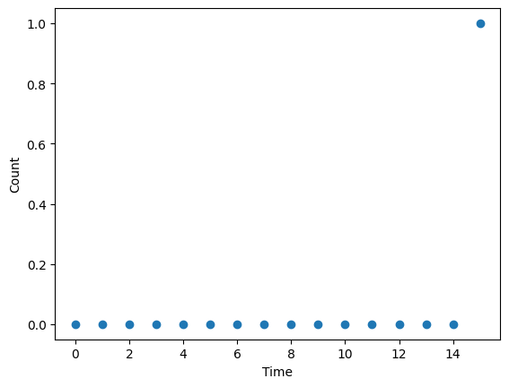

```python
n_timepoints = 16
t = np.arange(n_timepoints)
example_counts = np.zeros(n_timepoints)
example_counts[-1] = 1

plt.scatter(t, example_counts)
plt.xlabel("Time")
plt.ylabel("Count")
```

We fit the model:

```
                 Generalized Linear Model Regression Results
==============================================================================
Dep. Variable:                      y   No. Observations:                   16
Model:                            GLM   Df Residuals:                       14
Model Family:                 Poisson   Df Model:                            1
Link Function:                    Log   Scale:                          1.0000
Method:                          IRLS   Log-Likelihood:                -1.0085
Date:                Tue, 08 Nov 2022   Deviance:                     0.016985
Time:                        06:43:59   Pearson chi2:                  0.00852
No. Iterations:                   100   Pseudo R-squ. (CS):             0.2921
Covariance Type:            nonrobust
==============================================================================
                 coef    std err          z      P>|z|      [0.025      0.975]
------------------------------------------------------------------------------
const        -71.6005      1.271    -56.315      0.000     -74.092     -69.109
x1             4.7728      0.108     44.232      0.000       4.561       4.984
==============================================================================
```

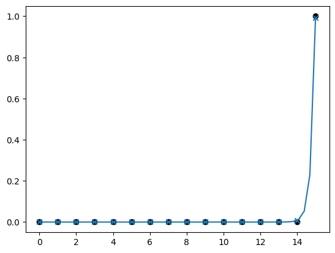

```python
results = poisson_regression(example_counts)
print(results.summary())

t_continuous = np.linspace(t[0], t[-1], 50)
pred = results.predict(sm.add_constant(t_continuous))
plt.plot(t_continuous, pred, 'C0')
plt.scatter(t, example_counts, color='k')
plt.scatter(t, results.fittedvalues, marker='x')
```

We're able to fit the points by picking a very small initial value and a fast growth rate. Note that the model is essentially infinitely confident that this data represents growth: for $\hat{\beta_1}$, $p \approx 0$ and the confidence bands are very tight.

But do we believe it? The null model is that the true Poisson intensity is constant: $\lambda_j = 1/n$. Let's calculate the true p-value, the probability under the null model that we get a $\hat{\beta_1}$ greater than or equal to the one we inferred from the data. In this simple case, we can do the calculation analytically. Then, we'll check the calculation with simulations.

First of all, when do we expect extreme values of $(\hat{\beta_0}, \hat{\beta_1})$? Intuitively, any case similar to our example will be best fit by small $\beta_0$ and large $\beta_1$. Consider $\vec{k} = (0, \ldots, 0, k)$ for $k>0$. For this $\vec(k)$, the maximum likelihood estimators are given by:

$$ \begin{align} \sum_{j=0}^{n-1} \exp(\hat{\beta_0} + \hat{\beta_1} j) & = k \\ \exp(\hat{\beta_0} + \hat{\beta_1} (n-1)) &= k \end{align} $$

Subtracting the second equation from the first, we get: $$ \sum_{j=0}^{n-2} \exp(\hat{\beta_0} + \hat{\beta_1} j) = 0 $$ This equation and the second above can be solved by letting $\hat{\beta_0} \to - \infty$ and $\hat{\beta_1} \to \infty$ so that $$ \hat{\beta_0} + \hat{\beta_1}(n-1) \to \log(k). $$

We can learn two things from this result. First, whenever we observe $\vec{k} = (0, \ldots, 0, k)$, the maximum likelihood coefficients are infinite. Second, that when $k=1$, we expect $$ \frac{\hat{\beta_0}}{\hat{\beta_1}} \sim -(n-1). $$

Let's test this:

```python
def fit_edge_case(n):
    counts = np.zeros(n)
    counts[-1] = 1
    return poisson_regression(counts)

ns = range(4, 11)
edge_case_params = [fit_edge_case(n).params for n in ns]
for n, (b0, b1) in zip(ns, edge_case_params):
    print(n, b0, b1, b0 / b1, sep='\t')
```

```
4	-54.27557253335197	18.091857508053636	-3.000000000508022
5	-58.99368263461413	14.748420584895545	-4.000000020004308
6	-62.628648399996536	12.525729098880852	-5.000000231969912
7	-64.28799597199003	10.714662909647624	-6.0000017279222355
8	-65.51655698264325	9.35949759186945	-7.000007889265035
9	-66.3680157024288	8.295974668908709	-8.0000263201333
10	-67.49096173945284	7.498941052682477	-9.000065644643302
```

Checks out.

We can see what's going on here by considering $n=2$ and varying $\beta_0 = -\beta_1$:

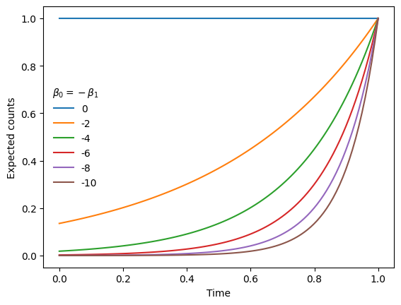

```python
x = np.linspace(0, 1, 100)
bs = range(0, 11, 2)
for b in bs:
    plt.plot(x, np.exp(-b + b*x), label = -b)
plt.legend(title=r"$\beta_0 = -\beta_1$")
plt.xlabel("Time")
plt.ylabel("Expected counts")
```

As $|\beta_1| = |\beta_0|$ gets larger, the expected count curve gets sharper, so that it gets closer to zero at $t<1$. The curve always goes through the point $(1,1)$.

Assuming these are the only cases that generate $\hat{\beta_1}$ this large, we can compute the p-value by looking at the probability of observing any $\vec{k}$ of the form $(0,\ldots,0,k)$, with $k>0$ under the null hypothesis. Because the $\{k_j\}$ are IID Poisson($1/n$), we have $$ \begin{align} p & = p_0^{n-1} (1 - p_0) \\ & = \exp\left(-\frac{n-1}{n}\right)\left(1 - \exp\left(-\frac{1}{n}\right)\right) \\ & \sim \frac{1}{en},\, \text{as}\, n\to\infty. \end{align} $$

We can check the asymptotic formula:

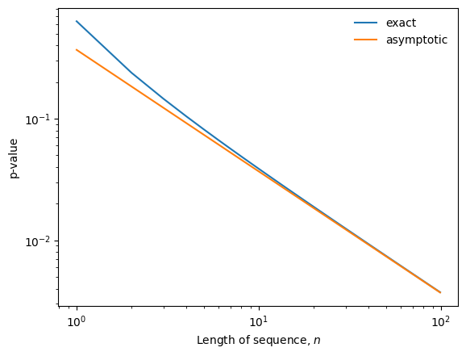

```python
def expected_p_value(n):
    return np.exp(-(n-1)/n)*(1-np.exp(-1/n))

n = np.arange(1, 100)
plt.loglog(n, expected_p_value(n), label="exact")
plt.loglog(n, 1/(np.exp(1)*n), label="asymptotic")
plt.legend()
plt.xlabel("Length of sequence, $n$")
plt.ylabel("p-value")
```

In our example above, we had $n = 16$ so we should have had $p \approx \frac{1}{en} \approx 0.023$, which is kind of small but not smaller than machine precision as predicted by the GLM software.

We can test the formulas above by sampling $\vec{k}$ under the null hypothesis of constant $\lambda$ and fitting the GLM to each sample. This will give us a distribution of $\left(\hat{\beta_0}, \hat{\beta_1}\right)$ under the null model.

```python
def sample_fits(expected_counts, n_sims, rng):
    for i in range(n_sims):
        simulated_counts = rng.poisson(expected_counts)
        if np.all(simulated_counts == simulated_counts[0]):
            # FIXME: should yield something more informative
            yield None
        else:
            yield poisson_regression(simulated_counts)

def sample_parameters(expected_counts, n_sims, rng):
    sp = [
        fit.params if fit else [0.0, 0.0]
        for fit in sample_fits(expected_counts, n_sims, rng)
    ]
    return np.array(sp)
```

```python
simulated_params = sample_parameters(results.null, 10000, rng)
```

Let's make a scatterplot of the joint null distribution:

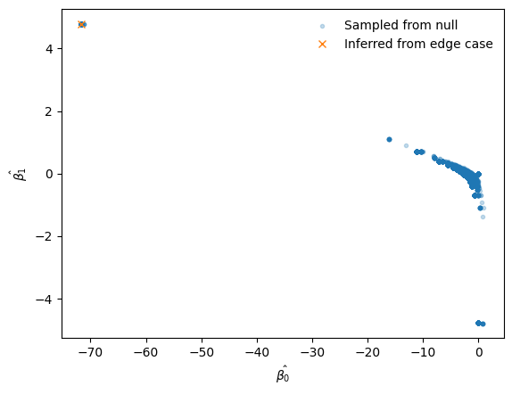

```python
plt.plot(simulated_params[:, 0], simulated_params[:, 1], '.', alpha=0.25, label="Sampled from null")
plt.plot(results.params[0], results.params[1], 'x', label="Inferred from edge case")
plt.legend()
plt.xlabel(r"$\hat{\beta_0}$")
plt.ylabel(r"$\hat{\beta_1}$")
```

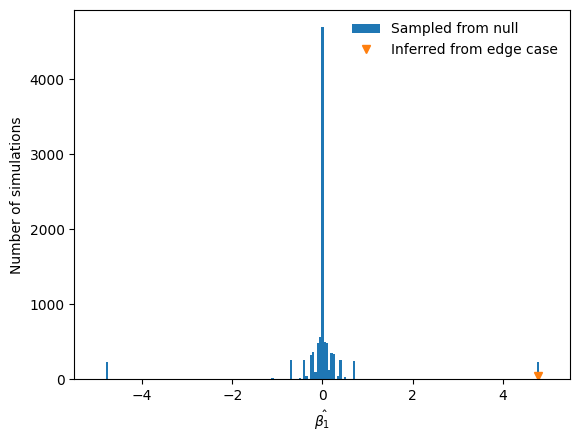

```python
plt.hist(simulated_params[:,1], bins=np.linspace(-5, 5, 200), label="Sampled from null")
plt.plot(results.params[1], 40, 'v', label="Inferred from edge case")
plt.legend()
plt.ylabel(r"Number of simulations")
plt.xlabel(r"$\hat{\beta_1}$")
```

It's clear from these plot that there's a cluster of "reasonable" paramters near zero, and then some outliers, which reflect the edge case that we're examining. Let's compute the simulated p-value and compare it to our expectation.

```python
def simulated_p_value(model_fit, null_params):
    return np.mean(np.abs(null_params[:,1]) >= np.abs(model_fit.params[1]))
```

```python
simulated_p_value(results, simulated_params)
```

```
0.0247
```

```python
expected_p_value(n_timepoints)
```

```
0.023726185505356663
```

That's within the margin of error for our 10,000 samples, and certainly better than the GLM software's estimate.

Before moving on from this edge case, let's compare the expected and software-estimated p-values for this edge case with different sequence lengths to show just how miscalibrated these p-values can be. Note that it's also possible for the software to overestimate the p-value.

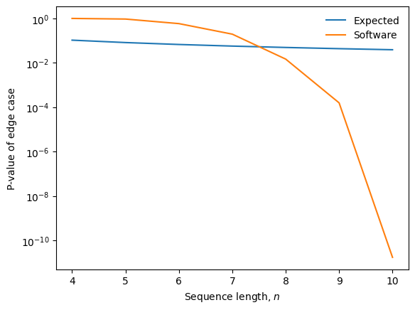

```python
ns = list(range(4, 11))
pvalues = [fit_edge_case(n).pvalues[1] for n in ns]
params = [fit_edge_case(n).params for n in ns]
pvalues_exp = [expected_p_value(n) for n in ns]

plt.semilogy(ns, pvalues_exp, label="Expected")
plt.semilogy(ns, pvalues, label="Software")
plt.legend()
plt.xlabel("Sequence length, $n$")
plt.ylabel("P-value of edge case")
```

## The sampling distribution of $\hat{\beta_1}$

In this section we're going to be using simulations to approximate the sampling distribution of our regression coefficient $\hat{\beta_1}$ under the null model of no growth ($\beta_1 = 0$) and under the alternative model with exponential growth ($\beta_1>0$). To compare models on an even footing, we'll compare growth and null models with the same total expected count: $$ \begin{align} \mathbb{E}\left[\sum_{j=0}^{n-1} k_j\right] & = \sum_{j=0}^{n-1} \exp\left(\beta_0 + \beta_1 j\right) \\ & = e^{\beta_0}\left(\frac{e^{\beta_1 n} - 1}{e^{\beta_1} - 1}\right) \end{align} $$

For simplicity, in this notebook, we'll be just looking at $\beta_1 = 0.2$ and a series of 32 samples. By varying the expected total count (and thereby $\beta_0$), we are effectively varying the sampling effort.

```python
def expected_counts(b0, b1, len_series):
    return np.exp(b0 + b1 * np.arange(len_series))

def expected_total_count(b0, b1, len_series):
    return np.exp(b0) * np.expm1(len_series * b1) / np.expm1(b1)

def inv_expected_total_count(total_count, b1, len_series):
    """Given a total count and a b_1, find the b_0 that gives the same expected total count."""
    return np.log(total_count) + np.log(np.expm1(b1) / np.expm1(len_series * b1))
```

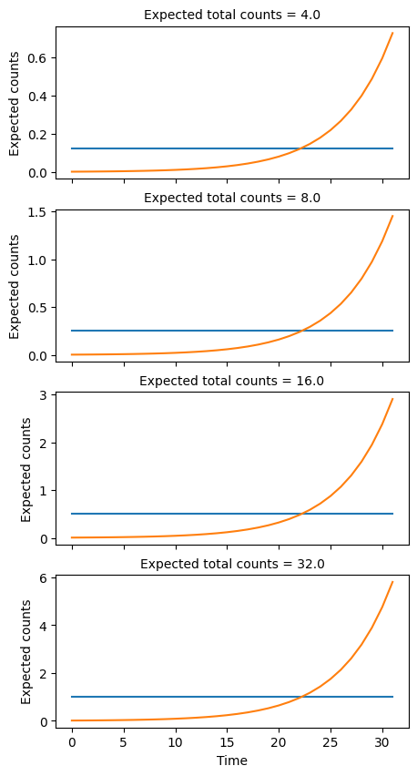

```python
beta1 = 0.2
len_series = 32
total_counts = np.logspace(2, 5, 4, base=2)
beta0_nulls = np.log(total_counts / len_series)
beta0_alts = np.array(
    [inv_expected_total_count(tc, beta1, len_series) for tc in total_counts]
)

lambda_nulls = [expected_counts(b0, 0, len_series) for b0 in beta0_nulls]
lambda_alts = [expected_counts(b0, beta1, len_series) for b0 in beta0_alts]

fig, axes = plt.subplots(len(total_counts), 1, sharex=True, figsize=(5,10))
for ax, tc, ln, la in zip(axes, total_counts, lambda_nulls, lambda_alts):
    ax.plot(ln)
    ax.plot(la)
    ax.set_ylabel("Expected counts")
    ax.set_title(f"Expected total counts = {tc}")
ax.set_xlabel("Time")
```

Let's simulate 10,000 samples from each model and make histograms of the inferred $\hat{\beta_1}$.

```python
n_sims = 10000

params_null = [
    sample_parameters(lamb, n_sims, rng)
    for lamb in lambda_nulls
]

params_alt = [
    sample_parameters(lamb, n_sims, rng)
    for lamb in lambda_alts
]
```

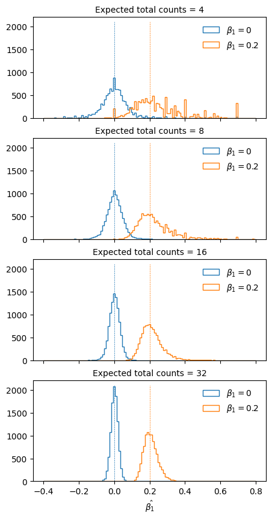

```python
fig, axes = plt.subplots(len(total_counts), 1, sharex=True, figsize=(5,10))
bins = np.linspace(-0.4, 0.8, 120)
for ax, tc, betas_null, betas_alt in zip(axes, total_counts, params_null, params_alt):
    ax.hist(betas_null[:,1], bins=bins, histtype="step", label=r"$\beta_1 = 0$")
    ax.hist(betas_alt[:,1], bins=bins, histtype="step", label=r"$\beta_1 = $" + str(beta1))
    ax.vlines([0.0], ymin=0, ymax=2100, color='C0', linestyle="dashed", lw=0.5)
    ax.vlines([0.2], ymin=0, ymax=2100, color='C1', linestyle="dashed", lw=0.5)
    ax.legend()
    ax.set_title(f"Expected total counts = {int(tc)}")
ax.set_xlabel(r"$\hat{\beta_1}$")
```

Some things to notice about these plots:

1. The distribution of $\hat{\beta_1}$ is centered around the true $\beta_1$. (Although the distributions are skewed in some cases).
2. The variance of the distributions decrease as the expected counts get higher. As a result, there is less overlap between the null and alternative distributions. This means more power to detect growth.
3. The distributions don't look particularly Gaussian.

Let's try to quantify these observations.

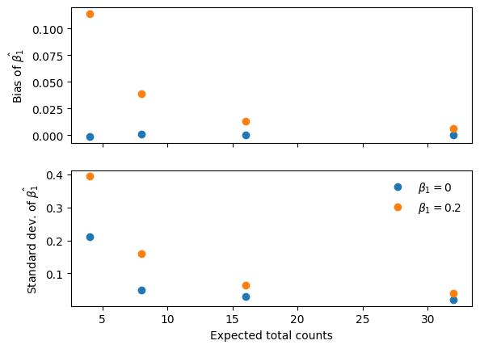

```python
bias_null = [np.mean(b[:, 1]) for b in params_null]
variance_null = [np.var(b[:, 1]) for b in params_null]
bias_alt = [np.mean(b[:, 1]) - beta1 for b in params_alt]
variance_alt = [np.var(b[:, 1]) for b in params_alt]

fig, ax = plt.subplots(2, 1, sharex=True)
ax[0].plot(total_counts, bias_null, 'o')
ax[0].plot(total_counts, bias_alt, 'o')
ax[0].set_ylabel(r"Bias of $\hat{\beta_1}$")

ax[1].plot(total_counts, np.sqrt(variance_null), 'o', label=r"$\beta_1 = 0$")
ax[1].plot(total_counts, np.sqrt(variance_alt), 'o', label=r"$\beta_1 = $" + str(beta1))
ax[1].legend()
ax[1].set_ylabel(r"Standard dev. of $\hat{\beta_1}$")
ax[1].set_xlabel("Expected total counts")
```

From these plots we can see:

1. For low-count data, the growth rate estimates are upwardly biased.
2. The standard deviations decrease with greater total counts for both models.
3. At all expected counts, the standard deviation is higher under the alternative model than the null.

This last observation is particularly important because it violates one of the assumptions of the GLM software p-values: that the variance in the estimator is independent of the true value of $\beta_1$.

Now we'll check the other key assumption: that the estimates $\hat{\beta_1}$ are Gaussian. To do that, we'll make some quantile plots, which plot the ordered values of the data vs the theoretical quantiles under the Gaussian distribution. If the data were perfectly Gaussian, they would fall exactly on the straight line.

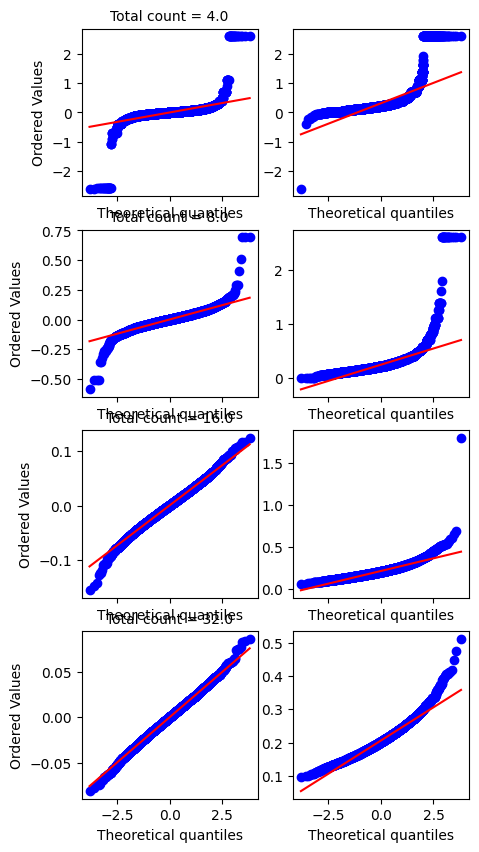

```python
fig, axes = plt.subplots(len(total_counts), 2, sharex=True, sharey=False, figsize=(5,10))
for ax, tc, betas_null, betas_alt in zip(axes, total_counts, params_null, params_alt):
    probplot(betas_null[:,1], plot=ax[0])
    probplot(betas_alt[:,1], plot=ax[1])
    ax[0].set_title(f"Total count = {tc}")
    ax[1].set_title("")
    ax[1].set_ylabel("")
```

It's clear that most of these distributions are very non-Gaussian. For the null distributions, the deviations are in the tails, which are particularly important for computing p-values.

The distributions (especially the null) become much more Gaussian with more data, as expected. But we would need more simulations (and likely importance sampling) to investigate the shape of the extreme tails.

## Standard errors

For large datasets, the covariance matrix of parameter estimates approaches the inverse of the Fisher Information matrix: $$ \mathcal{I}_{ij}(\beta_0, \beta_1) = - \mathbb{E}\left[\frac{\partial^2}{\partial \beta_i \partial \beta_j }l(\beta_0, \beta_1; \vec{k})\right]. $$

In our model we have: $$ \begin{align} \mathcal{I}_{00} & = \sum_j \lambda_j \\ \mathcal{I}_{01} & = \mathcal{I}_{10} = \sum_j \lambda_j j \\ \mathcal{I}_{11} & = \sum_j \lambda_j j^2 \\ \end{align} $$

Let's compute the expectations for our sample parameter values from the previous section:

```python
def cov_from_fisher_information(lambdas):
    i00 = np.sum(lambdas)
    i01 = np.dot(lambdas, np.arange(len(lambdas)))
    i11 = np.dot(lambdas, np.arange(len(lambdas))**2)
    I = np.array([[i00, i01], [i01, i11]])
    return np.linalg.inv(I)
```

```python
var_fi_null = np.array([
    cov_from_fisher_information(l)[1,1]
    for l in lambda_nulls
])

var_fi_alt = np.array([
    cov_from_fisher_information(l)[1,1]
    for l in lambda_alts
])
```

We can compare the observed standard deviations (standard errors) of $\hat{\beta_1}$ in our simulations to the theoretical predictions for the null model and the model with growth:

```
(0.0, 0.45)
```

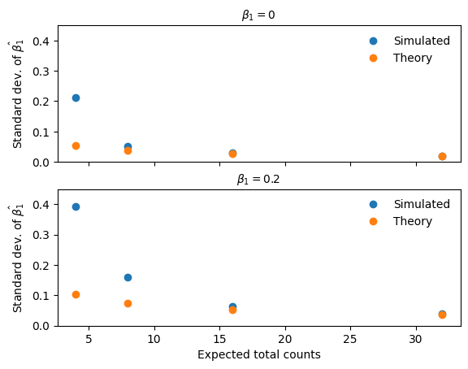

```python
fig, ax = plt.subplots(2, 1, sharex=True)

ax[0].plot(total_counts, np.sqrt(variance_null), 'o', label=r"Simulated")
ax[0].plot(total_counts, np.sqrt(var_fi_null), 'o', label=r"Theory")
ax[0].legend()
ax[0].set_ylabel(r"Standard dev. of $\hat{\beta_1}$")
ax[0].set_title(r"$\beta_1 = 0$")
ax[0].set_ylim([0, 0.45])

ax[1].plot(total_counts, np.sqrt(variance_alt), 'o', label=r"Simulated")
ax[1].plot(total_counts, np.sqrt(var_fi_alt), 'o', label=r"Theory")
ax[1].legend()
ax[1].set_ylabel(r"Standard dev. of $\hat{\beta_1}$")
ax[1].set_xlabel("Expected total counts")
ax[1].set_title(r"$\beta_1 = $" + str(beta1))
ax[1].set_ylim([0, 0.45])
```

In both cases, the theory underestimates the variance in the estimator compared to thi simulations, but the estimates become more accurate as the expected total counts grows. We plot the ratio of simulated to theory in the next cell.

```
(1.0, 4.0)
```

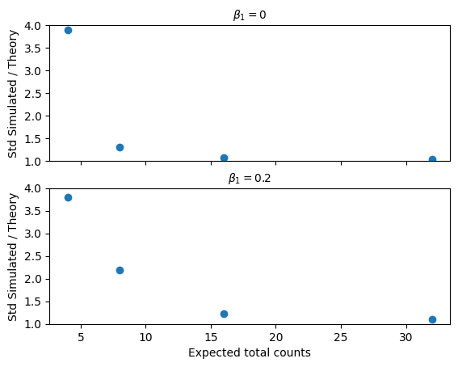

```python
fig, ax = plt.subplots(2, 1, sharex=True)

ax[0].plot(total_counts, np.sqrt(variance_null) / np.sqrt(var_fi_null), 'o', label=r"Theory")
ax[0].set_ylabel(r"Std Simulated / Theory")
ax[0].set_title(r"$\beta_1 = 0$")
ax[0].set_ylim([1, 4])

ax[1].plot(total_counts, np.sqrt(variance_alt) / np.sqrt(var_fi_alt), 'o', label=r"Theory")
ax[1].set_ylabel(r"Std Simulated / Theory")
ax[1].set_xlabel("Expected total counts")
ax[1].set_title(r"$\beta_1 = $" + str(beta1))
ax[1].set_ylim([1, 4])
```

We now have two reasons not to trust the standard errors predicted by the software:

1. The true standard error depends on the true value of $\beta_1$.
2. For low expected total counts, the true standard error is larger than predicted by the Fisher Information.

The combination of the non-Gaussian sampling distributions illustrated in the previous section with the problems with the standard errors illustrated here mean that the p-values generated by the software will be garbled, with effects in different directions. On one hand, the fact that the sampling distribution has smaller standard deviation under the null hypothesis than under the alternative will tend to make the software's p-values conservative. On the other hand, the Fisher information—based approximations are smaller than the true standard deviations, which will tend to make the software's p-values too small. Finally, the non-Gaussian sampling distribution, especially the fat tails illustrated on the quantile plots above, will also make the software's p-values too small. This last effect will be particularly important in the tails of the distribution and make very small p-values particularly mis-calibrated.

## Calibration of p-values

In theory a p-value is the probability of inferring a parameter value at least as large as the observed value when the data is drawn from the null hypothesis. In practice, it is common to use approximations and asymptotic formulas to approximate this value. By *calibration*, I mean that the approximate p-values are close to the true probability under the null, which we can compute by simulation.

In practice, what we really care about are the calibration of small p-values. It does not particularly concern us if we think a p-value should be 0.45 and our procedure returns 0.25. But we may care a lot if the the true p-value is 0.01 and the procedure returns $10^{-6}$.

We may also be especially concerned if the conflicted effects described at the end of the last section mean that we can't trust the ordering of the software-generated p-values to preserve the ordering of the true p-values.

The difficulty of calculating the calibration for small p-values is that, by definition, they should involve counting very rare events in our simulations, and thus be very noisy. A standard way to efficiently sample rare events is *importance sampling.* With importance sampling, you simulate data from a different model and then use the likelihood ratio between the simulated model and the target model to weight your simulations. In our case, we could simulate data under a model with growth and then use the likelihood ratio to compute the probability of observing the data under the null model with no growth.

TODO: Use importance sampling to compute p-values and make calibration curves.

## Coverage of confidence intervals

A confidence interval is a pair of functions of the data $lb(\vec{k}), ub(\vec{k})$ with the property that the true value of a parameter should fall between $lb$ and $ub$ with a set probability, often 95%.

For a particular procedure for calculating a confidence interval, the *coverage* is the actual fraction of the time that the true parameter falls within the interval.

Our GLM software reports confidence intervals using the approximations described above and we can use our simulations to calcuate coverage:

```python
def sample_conf_int(expected_counts, n_sims, rng):
    sci = [fit.conf_int()[1] if fit else [0.0, 0.0] for fit in sample_fits(expected_counts, n_sims, rng)]
    return np.array(sci)

def coverage(ci, true_value):
    return np.mean((ci[:, 0] < true_value) & (ci[:, 1] > true_value))
```

```python
ci_null = [
    sample_conf_int(lamb, n_sims, rng)
    for lamb in lambda_nulls
]

ci_alt = [
    sample_conf_int(lamb, n_sims, rng)
    for lamb in lambda_alts
]
```

```python
for tc, ci_n, ci_a in zip(total_counts, ci_null, ci_alt):
    print(tc, coverage(ci_n, 0.0), coverage(ci_a, beta1), sep='\t')
```

```
4.0	0.966	0.9265
8.0	0.9703	0.9565
16.0	0.958	0.9562
32.0	0.9534	0.9538
```

Interestingly, despite the issues illustrated above, these 95% confidence intervals are not terribly off. For both the model with growth and the constant model, the true value tends to fall within the confidence interval roughly 95% of the time. This suggests that some of the errors pointing in opposite directions are canceling out. Whether this is something we can count on is an open question.

Also, just because the 95% confidence interval has proper coverage, does not guarantee that we can extrapolate from the CI to a p-value, because p-values depend sensitively on the tails of the distribution.

## Next steps

- See if we can use the distributions of the sufficient statistics to get better analytical approximations and scaling laws.
- Impliment importance sampling to estimate the tails of the sampling distribution of $\hat{beta_1}$ and investigate small p-values.
- Investigate the effects of varying the number of samples and the growth rate. (This can be done both numerically and also analytically because there are relationships between paramters like growth rate and sampling frequency that should allow us to scale our existing results.)
- Apply this analysis to regularized estimates like elastic net or Bayes.
- Investigate the effects of overdispersed counts.